# SD_12_RECO_EXP_ADD_L2A_2D

Lines 2a through 2d · Amount report

## Overview

**Description**

Total amounts; add lines 2a through 2d

**Table**

`SD-P12-T00-RECONCILIATION-EXPENSES` (one)

**Location code**

`SCHED-D-PART-12-LINE-02E`

**Family**

`SCHED-D-PART-12-LINE-02E`

**Data type**

numeric (xsd: USAmountType, )

**Scope**

PC

**Status**

unreviewed

3

xpaths mapped (2 observed)

969,182

filings with a value

2009–2024

tax years observed

3

open flags (2 errors)

## Flags

| Severity | Flag | Xpath | Detail |
| --- | --- | --- | --- |
| ⚠ error | `POLARITY` | IRS990ScheduleD/ExpensesNotReportedAmt | negated element ‘ExpensesNotReportedAmt’ pooled with non-negated xpaths |
| ⚠ error | `POLARITY` | IRS990ScheduleD/ExpensesNotRptdF990 | negated element ‘ExpensesNotRptdF990’ pooled with non-negated xpaths |
| ⓘ info | `UNOBSERVED` | IRS990ScheduleD/Form990ScheduleDPartXIII/TotalAmountsLine2aTo2d | never observed in TY2009-2024 filings |

## Xpaths

All mapped xpaths (under /Return/ReturnData or /Return/ReturnHeader), oldest first. Charts label each series by its xpath.

| Xpath | Form | Chart label | First year | Last year | Versions | Filings | Repeats in |
| --- | --- | --- | --- | --- | --- | --- | --- |
| IRS990ScheduleD/ExpensesNotRptdF990 | Sched D | same | 2009 | 2012 | 18 | 166,187 | 0.0% |
| IRS990ScheduleD/ExpensesNotReportedAmt | Sched D | same | 2013 | 2024 | 37 | 802,995 | 0.0% |
| IRS990ScheduleD/Form990ScheduleDPartXIII/TotalAmountsLine2aTo2d | Sched D | …ScheduleD/Form990ScheduleDPartXIII/TotalAmountsLine2aTo2d |  |  |  | 0 |  |

## Coverage

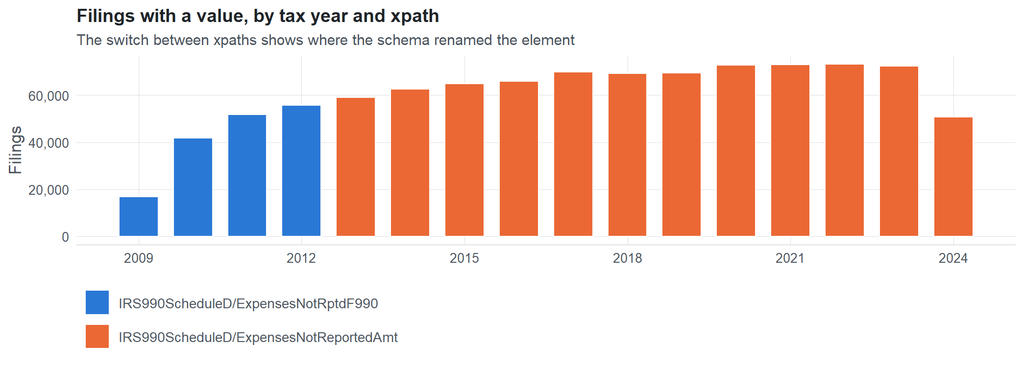

**Table view**

Table view: filings by tax year and series

| Tax year | IRS990ScheduleD/ExpensesNotRptdF990 | IRS990ScheduleD/ExpensesNotReportedAmt |
| --- | --- | --- |
| 2009 | 16,911 | 0 |
| 2010 | 41,854 | 0 |
| 2011 | 51,674 | 0 |
| 2012 | 55,748 | 0 |
| 2013 | 0 | 59,025 |
| 2014 | 0 | 62,540 |
| 2015 | 0 | 64,970 |
| 2016 | 0 | 65,996 |
| 2017 | 0 | 69,828 |
| 2018 | 0 | 69,230 |
| 2019 | 0 | 69,414 |
| 2020 | 0 | 72,745 |
| 2021 | 0 | 73,086 |
| 2022 | 0 | 73,131 |
| 2023 | 0 | 72,388 |
| 2024 | 0 | 50,642 |

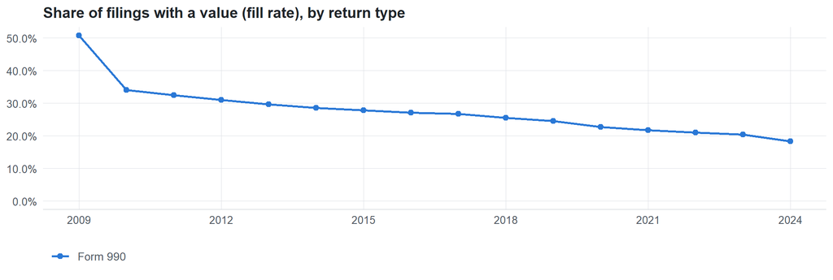

**Table view**

Table view: fill rate

| Tax year | Return type | Filings | All filings | Fill rate |
| --- | --- | --- | --- | --- |
| 2009 | Form 990 | 16,911 | 33,311 | 50.77% |
| 2010 | Form 990 | 41,854 | 123,025 | 34.02% |
| 2011 | Form 990 | 51,674 | 159,504 | 32.40% |
| 2012 | Form 990 | 55,748 | 179,688 | 31.02% |
| 2013 | Form 990 | 59,025 | 198,855 | 29.68% |
| 2014 | Form 990 | 62,540 | 218,619 | 28.61% |
| 2015 | Form 990 | 64,970 | 233,519 | 27.82% |
| 2016 | Form 990 | 65,996 | 243,903 | 27.06% |
| 2017 | Form 990 | 69,828 | 261,612 | 26.69% |
| 2018 | Form 990 | 69,230 | 271,442 | 25.50% |
| 2019 | Form 990 | 69,414 | 283,694 | 24.47% |
| 2020 | Form 990 | 72,745 | 320,342 | 22.71% |
| 2021 | Form 990 | 73,086 | 336,480 | 21.72% |
| 2022 | Form 990 | 73,131 | 349,055 | 20.95% |
| 2023 | Form 990 | 72,388 | 354,768 | 20.40% |
| 2024 | Form 990 | 50,642 | 277,298 | 18.26% |

## Values

| Result | Check | Detail |
| --- | --- | --- |
| ✓ pass | Values parse as numbers | 100.0% of values are numeric |
| ✓ pass | No sudden change in the median between adjacent years | largest change 4.6x (IRS990ScheduleD/ExpensesNotReportedAmt, 990, TY2022) |
| ✓ pass | Pooled xpaths are on the same scale (same return type) | largest ratio of medians between xpaths: 2.9x |
| ⓘ info | Sign convention | 1.7% of values are negative (fine for net amounts) |

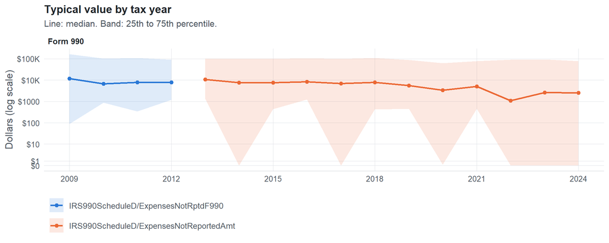

**Table view**

Table view: quartiles by tax year

| Series | Return | Tax year | Filings | P25 | Median | P75 |
| --- | --- | --- | --- | --- | --- | --- |
| IRS990ScheduleD/ExpensesNotRptdF990 | 990 | 2009 | 16,911 | 90.09 | 11,780 | 165,039 |
| IRS990ScheduleD/ExpensesNotRptdF990 | 990 | 2010 | 41,854 | 882.24 | 6,637 | 101,696 |
| IRS990ScheduleD/ExpensesNotRptdF990 | 990 | 2011 | 51,674 | 339.92 | 7,715 | 110,394 |
| IRS990ScheduleD/ExpensesNotRptdF990 | 990 | 2012 | 55,748 | 1,178 | 7,743 | 90,879 |
| IRS990ScheduleD/ExpensesNotReportedAmt | 990 | 2013 | 59,025 | 1,305 | 10,803 | 97,972 |
| IRS990ScheduleD/ExpensesNotReportedAmt | 990 | 2014 | 62,540 | 0 | 7,476 | 100,992 |
| IRS990ScheduleD/ExpensesNotReportedAmt | 990 | 2015 | 64,970 | 440.04 | 7,559 | 100,273 |
| IRS990ScheduleD/ExpensesNotReportedAmt | 990 | 2016 | 65,996 | 1,230 | 8,317 | 104,886 |
| IRS990ScheduleD/ExpensesNotReportedAmt | 990 | 2017 | 69,828 | 0 | 6,831 | 99,081 |
| IRS990ScheduleD/ExpensesNotReportedAmt | 990 | 2018 | 69,230 | 419.11 | 7,928 | 108,089 |
| IRS990ScheduleD/ExpensesNotReportedAmt | 990 | 2019 | 69,414 | 447.24 | 5,616 | 86,747 |
| IRS990ScheduleD/ExpensesNotReportedAmt | 990 | 2020 | 72,745 | 0.19 | 3,338 | 62,861 |
| IRS990ScheduleD/ExpensesNotReportedAmt | 990 | 2021 | 73,086 | 451.24 | 4,998 | 77,401 |
| IRS990ScheduleD/ExpensesNotReportedAmt | 990 | 2022 | 73,131 | 0 | 1,096 | 90,351 |
| IRS990ScheduleD/ExpensesNotReportedAmt | 990 | 2023 | 72,388 | 0 | 2,593 | 93,567 |
| IRS990ScheduleD/ExpensesNotReportedAmt | 990 | 2024 | 50,642 | 0 | 2,498 | 76,541 |

Summary by xpath and return type (all years)

[output not shown]

## Examples

| Tax year | Return | Xpath | Organization | Value | Source |
| --- | --- | --- | --- | --- | --- |
| 2024 | 990 | IRS990ScheduleD/ExpensesNotReportedAmt | RISEWELL COMMUNITY SERVICES INC FKA | 32435 | [XML](https://gt990datalake-rawdata.s3.amazonaws.com/EfileData/XmlFiles/202610589349301811_public.xml) |
| 2023 | 990 | IRS990ScheduleD/ExpensesNotReportedAmt | ZEPF CENTER | 25354 | [XML](https://gt990datalake-rawdata.s3.amazonaws.com/EfileData/XmlFiles/202423399349300887_public.xml) |
| 2022 | 990 | IRS990ScheduleD/ExpensesNotReportedAmt | CANTERBURY TOWER INC | 0 | [XML](https://gt990datalake-rawdata.s3.amazonaws.com/EfileData/XmlFiles/202332979349301963_public.xml) |
| 2021 | 990 | IRS990ScheduleD/ExpensesNotReportedAmt | AFRICA NETWORK FOR ANIMAL WELFARE- USA | 0 | [XML](https://gt990datalake-rawdata.s3.amazonaws.com/EfileData/XmlFiles/202222209349300402_public.xml) |
| 2020 | 990 | IRS990ScheduleD/ExpensesNotReportedAmt | CHARLOTTE HARBOR WATER ASSOCIATION INC | 0 | [XML](https://gt990datalake-rawdata.s3.amazonaws.com/EfileData/XmlFiles/202132739349301608_public.xml) |
| 2019 | 990 | IRS990ScheduleD/ExpensesNotReportedAmt | FRIENDS OF PEB INC | 0 | [XML](https://gt990datalake-rawdata.s3.amazonaws.com/EfileData/XmlFiles/202013109349302416_public.xml) |
| 2018 | 990 | IRS990ScheduleD/ExpensesNotReportedAmt | UA LOCAL NO 159 | 0 | [XML](https://gt990datalake-rawdata.s3.amazonaws.com/EfileData/XmlFiles/202000509349301025_public.xml) |
| 2017 | 990 | IRS990ScheduleD/ExpensesNotReportedAmt | ALBERT LEA TRADES & LABOR ASSEMBLY | 0 | [XML](https://gt990datalake-rawdata.s3.amazonaws.com/EfileData/XmlFiles/201912279349302731_public.xml) |
| 2016 | 990 | IRS990ScheduleD/ExpensesNotReportedAmt | HOME HEADQUARTERS INC | 4070 | [XML](https://gt990datalake-rawdata.s3.amazonaws.com/EfileData/XmlFiles/201723559349300012_public.xml) |
| 2015 | 990 | IRS990ScheduleD/ExpensesNotReportedAmt | FAMILY SERVICE ASSOCIATION OF GREATER | 117246 | [XML](https://gt990datalake-rawdata.s3.amazonaws.com/EfileData/XmlFiles/201711039349300326_public.xml) |
| 2014 | 990 | IRS990ScheduleD/ExpensesNotReportedAmt | JUDGES AND LAWYERS BREAST CANCER ALERT | 0 | [XML](https://gt990datalake-rawdata.s3.amazonaws.com/EfileData/XmlFiles/201601249349301520_public.xml) |
| 2013 | 990 | IRS990ScheduleD/ExpensesNotReportedAmt | THE COUNCIL ON ALCOHOLISM & DRUG | 0 | [XML](https://gt990datalake-rawdata.s3.amazonaws.com/EfileData/XmlFiles/201441989349300024_public.xml) |

## Reviewer checklist

- The definition matches the form line and instructions for every xpath’s schema years.
- Every xpath pooled here measures the same thing on the 990 and 990-EZ (close enough for analysis).
- The coverage chart has no unexplained gaps or jumps between tax years.
- Each open flag is fixed, or accepted with a note in validation_log.csv.
- Values are whole dollars, not thousands, and not a percentage.
- Current year / prior year and beginning / end of year match the variable name (CY, PY, BOY, EOY).
- Negative values are expected only for net amounts (gains, net income, fund balances).
- The 990 and 990-EZ medians differ only as much as the filer populations do.

Record the review as a row in `inst/extdata/src/validation_log.csv` (variable_name, reviewer, date, status, note). Evidence built 2026-09-23 17:09:04 MST from the ef2 DuckDB builds (tax years 2009–2024).